# Poverty Rate Analysis

Ruizhen Mai

5/14/2019

# Introduction

Per the instruction, in this project, I’m going to utilize the data in World Bank’s database and discover possible relations with the outcome variable *poverty*. To predict poverty, I’m going to include the following measurement:

- Unemployment Rate
- % of population has Access to Electricity
- Renewable Energy Consumption % of total energy consumption
- Birth Rate
- Children Mortality Rate
- Literacy Rate

*Unemployment Rate* represents a country’s current economic status. When a country is in bad situation, like in depression, then a lot of people are not likely to find jobs and thus will live in poverty. This should have positive relation with poverty.

*% of population has Access to Electricity* represents a conutry’s development status in terms of energy. Generally, a well developed conutry should allow almost all citizens to have access to electricity, as it is basically the standard of modernity. I expect this has negative relation with poverty.

*Renewable Energy Consumption % of total energy consumption* represents a country’s development in energy further. Renewable energy such as solar energy and wind power is expensive than fossil energy. Only those countries that are very well developed will have the money to spend on renewable energy.

*Birth rate* from another perspective measures a conutry’s development. Generally, developing country will tend to have high birth rate because their children are a type of resources, representing labor. They will tend to have more labor force to help out the family. In a developed country, birth rate tend to low because it’s costly to raise a baby. This should have negative relation with poevrty.

*Children Mortality Rate* is a proxy of a conutry’s medical level. In a conutry with sufficient and affordable medical treatment, the children mortality rate should be low. But in countries where there are a lot of poor people, it is less likely that this country has a lot of medical resources and their children will tend to die early. This should have positive relation with poverty.

*Literacy Rate* measures a conutry’s educational resources and percentage of people’s access to good occupation. A high literacy rate tends to represent a lot of people are educated, and educated people tend to find a job that can support themselves, and less likely to be poor. This rate is expected to be negatively related to poverty.

In this project I will focus with *unemployment rate*, but if any interesting outcome pops up I will also dig into it.

Below is the list of varaibles

```r
wb_variables <- c("SI.POV.DDAY",
                  "SI.POV.NAHC",
                  "SL.UEM.TOTL.ZS",
                  "EG.FEC.RNEW.ZS",
                  "EG.ELC.ACCS.ZS",
                  "SP.DYN.TFRT.IN",
                  "SH.DYN.MORT",
                  "SE.ADT.LITR.ZS",
                  "SP.DYN.LE00.IN"
                  )
# First Two are outcome variables
wb_names <- c("poverty_headcount_ratio_1.90",
              "poverty_headcount_ratio",
              "unemp_rate", # Unemployment Rate
              "renew_eng_consp_rate", # Renewable Energy consumption of total Energy consumption
              "acs_to_elec", # Percentage Access to Electricity
              "birth_rate", # Fertility rate, births per woman
              "childmort", # Moratility rate of child(under-5)
              "literacy_rate",
              "life_exp" # 后来加上来的，没用
              )
```

The first two, `poverty_headcount_ratio` and `poverty_headcount_ratio_1.90` are different measures of the poverty. First one represents the poverty rate accordind to that country’s standard. The second one is the rate according to an international standard – “the percentage of the population living on less than $1.90 a day at 2011 international prices”(World Bank).

The rest are the predictor variables. The comments explain what they are meant for.

### Download data

```r
wb_data <- wb(country = "all", indicator = wb_variables,
              startdate = 2007, enddate = 2018, return_wide = TRUE)

wb_recent <- wb_data %>%
  group_by(country) %>%
  arrange(desc(date)) %>%
  fill(wb_variables) %>% # fill NAs with value from most recent year
  drop_na() %>%
  top_n(n = 1, wt = date) %>%
  ungroup() %>%
  rename_at(vars(wb_variables), ~ wb_names)


nrow(wb_recent)
```

```
## [1] 115
```

# Analysis 1.

Analyze the data first with `poverty_headcount_ratio_1.90` the first outcome variable.

### Analysis of *poverty_headcount_ratio_1.90* simple model

First comes the simple linear model with only one predictor `unemp_rate`.

```r
# Create the Models
# Simple Model
linear_model_simple = lm(poverty_headcount_ratio_1.90~unemp_rate, data =wb_recent)
summary(linear_model_simple)
```

```
##
## Call:
## lm(formula = poverty_headcount_ratio_1.90 ~ unemp_rate, data = wb_recent)
##
## Residuals:
##    Min     1Q Median     3Q    Max
## -22.16 -16.50 -10.27  15.12  56.82
##
## Coefficients:
##             Estimate Std. Error t value Pr(>|t|)
## (Intercept)  22.5220     3.1985   7.041 1.58e-10 ***
## unemp_rate   -0.6122     0.3158  -1.939    0.055 .
## ---
## Signif. codes:  0 '***' 0.001 '**' 0.01 '*' 0.05 '.' 0.1 ' ' 1
##
## Residual standard error: 21.55 on 113 degrees of freedom
## Multiple R-squared:  0.03219,    Adjusted R-squared:  0.02362
## F-statistic: 3.758 on 1 and 113 DF,  p-value: 0.05504
```

- Umployment status does not directly mean this person is poor. From economics 101, umployment can be temporal, and a person who has savings but is unemployed is not poor
- The poverty measurement is an international standard, in countries with good national welfare such as Swiss and Dutch, even though a person is unemployed, it is possible that living with national welfare is not in poverty standard. In contrary, a people born in a less developed country, even he is employed, it is possible that he is in poverty
- In less developed country, the unemployment status may be not well recored. And probably many people do not register that they are employed, or they are doing not registered job still get paid.
- Measurement error on unemployment rate

```r
confint(linear_model_simple)
```

```
##                 2.5 %      97.5 %
## (Intercept) 16.185191 28.85876432
## unemp_rate  -1.237929  0.01343626
```

Checking the `confint(linear_model_simple)` we see a loose confidence intervals. On one right side, in terms of %, a -0.02 decrease in poverty rate percentage actually does not have much impact on the outcome. On the left side -1.2 is huge relatively. The confidence interval is too wide to reach practical siginificance conclusion.

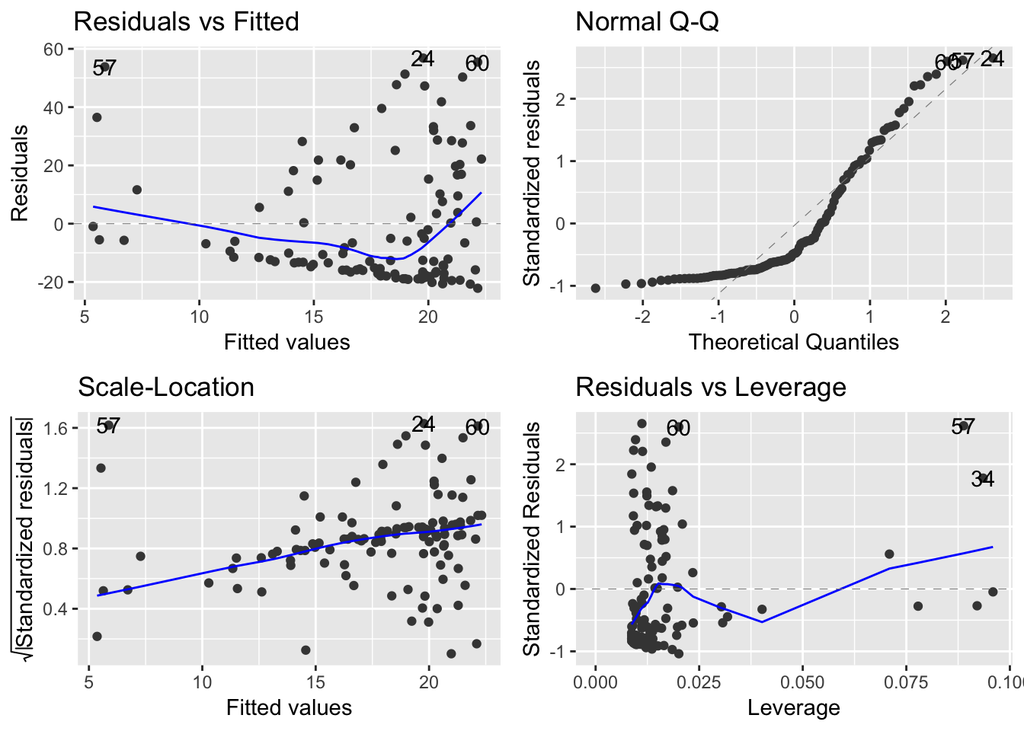

```r
autoplot(linear_model_simple)
```

Cheking the 4 plots it’s clear that the simple model has a lot of problems.

From *Residuals vs Fitted* it’s clear that the residuals have a nonlinear relation with fitted value. The simple model does not fit well. This is in line with the ~0.03 r-square score.

From *Normal Q-Q* , the residuals are not at the 45 degree line. They are in a *s-shaped*, and claerly not normally distributed. They have more of a bell shape curve like t distribution

From *Scale-Location*, it’s actually not bad and we cannot say the model has much heteroskadacity in terms of real-world data

From *Residuals vs Leverage* we see there are quite a few outliers

### Analysis of *poverty_headcount_ratio_1.90* complex model

Then I utilize all the predictors mentioned in the introduction to build the complex model

```r
# Complex Model
linear_model = lm(poverty_headcount_ratio_1.90~
                    unemp_rate+
                    renew_eng_consp_rate+
                    acs_to_elec+
                    birth_rate+
                    childmort+
                    literacy_rate+
                    life_exp, data = wb_recent)

summary(linear_model)
```

```
##
## Call:
## lm(formula = poverty_headcount_ratio_1.90 ~ unemp_rate + renew_eng_consp_rate +
##     acs_to_elec + birth_rate + childmort + literacy_rate + life_exp,
##     data = wb_recent)
##
## Residuals:
##      Min       1Q   Median       3Q      Max
## -25.9164  -4.0157   0.4559   3.4253  29.8915
##
## Coefficients:
##                      Estimate Std. Error t value Pr(>|t|)
## (Intercept)          35.48106   29.05481   1.221   0.2247
## unemp_rate           -0.04396    0.15540  -0.283   0.7778
## renew_eng_consp_rate  0.09301    0.05010   1.857   0.0661 .
## acs_to_elec          -0.47930    0.06646  -7.212 8.26e-11 ***
## birth_rate            0.53421    1.25734   0.425   0.6718
## childmort             0.08893    0.08816   1.009   0.3153
## literacy_rate         0.19247    0.09133   2.107   0.0374 *
## life_exp             -0.12600    0.33819  -0.373   0.7102
## ---
## Signif. codes:  0 '***' 0.001 '**' 0.01 '*' 0.05 '.' 0.1 ' ' 1
##
## Residual standard error: 9.479 on 107 degrees of freedom
## Multiple R-squared:  0.8226, Adjusted R-squared:  0.811
## F-statistic:  70.9 on 7 and 107 DF,  p-value: < 2.2e-16
```

Taking a closer look at their confidence interval:

```r
confint(linear_model)
```

```
##                              2.5 %     97.5 %
## (Intercept)          -22.116718530 93.0788329
## unemp_rate            -0.352017701  0.2641064
## renew_eng_consp_rate  -0.006303338  0.1923167
## acs_to_elec           -0.611054321 -0.3475523
## birth_rate            -1.958321388  3.0267418
## childmort             -0.085824866  0.2636894
## literacy_rate          0.011414046  0.3735221
## life_exp              -0.796421122  0.5444200
```

We see the confidence interval of *unemployment rate* ranges from negative to positive. This menas that the true unemployment rate coefficient can be postive and negative. Thus with the complex model, it further illustrates why the negative coefficient obtained in the simple model is not meaningful, since it bounces between negative and positive. From this point, statistically we see there is no (linear) correlation between *unemployment rate* and *poverty rate*, keeping other factors consant. Practically there is no significance either.

#### Other predictors

- Access to electricity is a very basic, necessary and important requirement for people. A government with money first thing will do is probably to develop electricity supply
- Measurement of Access to eletricity is a long-term factor and connot be changed in a few years, unlike unemployment rate. Poverty is also a long-term factor. The change in electricity fits the change of poverty rate well

Aside from electricity, other predictors do not demonstrate very influential effect. For `birth_rate` and `childmort`, we cannot even reject the null hypothesis. From a statistical standpoint, this is probably because the correlation of `acs_to_elec` is so strong that other predictors are trivial in comparison. Trying to explain it in a more practical way:

- birth_rate: there could be developed countries that have not low birth rates such as U.S. and China, this bias the prediction
- childmort: as long as a conutry is somewhat developed, the childmort will decrease very quick and to almost zero, the relation between childmort and poverty may not be linear

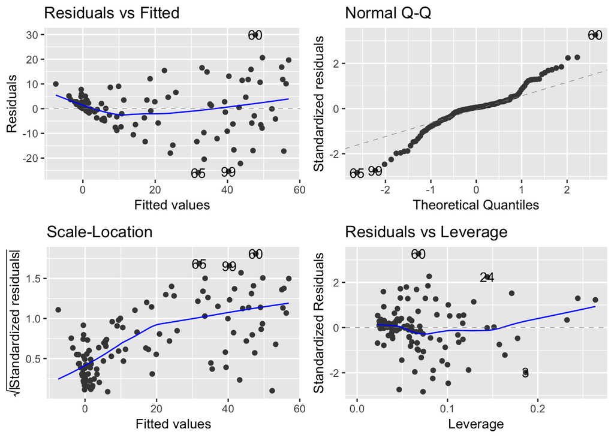

```r
autoplot(linear_model)
```

From *Residuals vs Fitted*, we see the residuals are clustered when fitted value is small. But generally there is no obvious non-linear pattern

From *Normal Q-Q* the residuals are more *s-shaped*. This implies the residuals are more in a bell-shaped distribution.

From *Scale-Location*, the residuals do seem come from two center point with two variance and in this model it does seem *heteroskadacity.*

From *Residuals vs Leverage* we see no obvious outliers

### Summary of complex model

In summary, we can neither find correlation between *unemployment rate* and *poverty rate* at this point, and nor practical significance on *unemployment rate*. Also, the diagnostic plots show the model has two problems: 1) residuals not normally distributed, 2) heteroskadacity. Thus again we shall not trust the inferences that much. For e.g., heteroskadacity means the data do not only has one variance, but in the linear regression we did we assumed they have only one. The coefficient predicted may not be that accurate.

### Comparison between Complex and Simple Model

```r
anova(linear_model_simple, linear_model)
```

```
## Analysis of Variance Table
##
## Model 1: poverty_headcount_ratio_1.90 ~ unemp_rate
## Model 2: poverty_headcount_ratio_1.90 ~ unemp_rate + renew_eng_consp_rate +
##     acs_to_elec + birth_rate + childmort + literacy_rate + life_exp
##   Res.Df   RSS Df Sum of Sq     F    Pr(>F)
## 1    113 52460
## 2    107  9614  6     42847 79.48 < 2.2e-16 ***
## ---
## Signif. codes:  0 '***' 0.001 '**' 0.01 '*' 0.05 '.' 0.1 ' ' 1
```

# Analysis 2.

### Analysis of *poverty_headcount_ratio* simple model

Analyze the data with second outcome `poverty_headcount_ratio`

```r
# Create the Models
# Simple Model
linear_model_simple2 = lm(poverty_headcount_ratio~unemp_rate, data =wb_recent)
summary(linear_model_simple)
```

```
##
## Call:
## lm(formula = poverty_headcount_ratio_1.90 ~ unemp_rate, data = wb_recent)
##
## Residuals:
##    Min     1Q Median     3Q    Max
## -22.16 -16.50 -10.27  15.12  56.82
##
## Coefficients:
##             Estimate Std. Error t value Pr(>|t|)
## (Intercept)  22.5220     3.1985   7.041 1.58e-10 ***
## unemp_rate   -0.6122     0.3158  -1.939    0.055 .
## ---
## Signif. codes:  0 '***' 0.001 '**' 0.01 '*' 0.05 '.' 0.1 ' ' 1
##
## Residual standard error: 21.55 on 113 degrees of freedom
## Multiple R-squared:  0.03219,    Adjusted R-squared:  0.02362
## F-statistic: 3.758 on 1 and 113 DF,  p-value: 0.05504
```

```r
confint(linear_model_simple2)
```

```
##                  2.5 %     97.5 %
## (Intercept) 25.6107631 35.9919363
## unemp_rate  -0.4924864  0.5325315
```

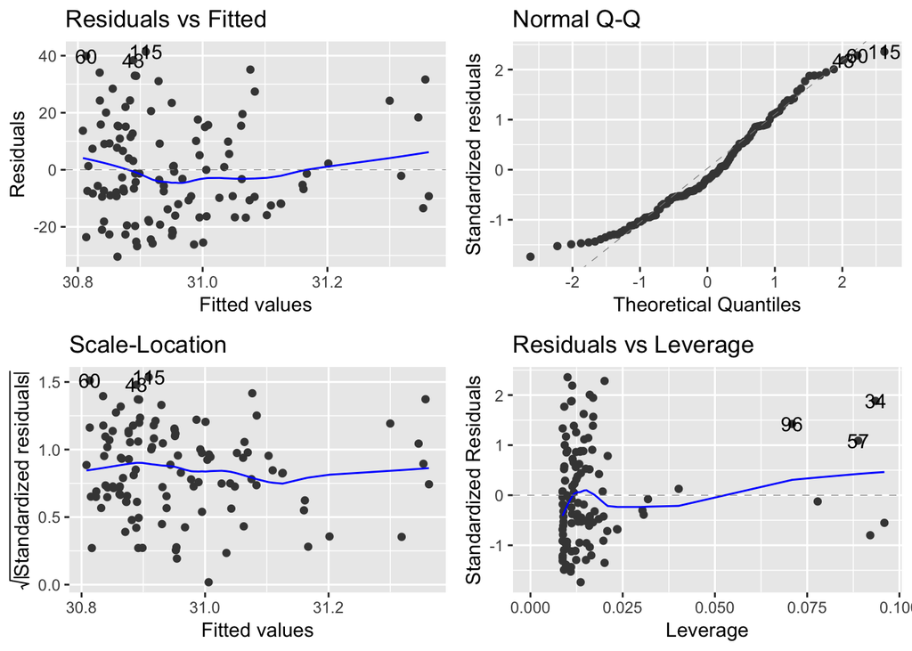

```r
autoplot(linear_model_simple2)
```

### Summary of Simple Model

```r
# Complex Model
linear_model2 = lm(poverty_headcount_ratio_1.90~
                    unemp_rate+
                    renew_eng_consp_rate+
                    acs_to_elec+
                    birth_rate+
                    childmort+
                    literacy_rate, data = wb_recent)

summary(linear_model2)
```

```
##
## Call:
## lm(formula = poverty_headcount_ratio_1.90 ~ unemp_rate + renew_eng_consp_rate +
##     acs_to_elec + birth_rate + childmort + literacy_rate, data = wb_recent)
##
## Residuals:
##      Min       1Q   Median       3Q      Max
## -26.4224  -4.0005   0.5066   3.4675  29.6296
##
## Coefficients:
##                      Estimate Std. Error t value Pr(>|t|)
## (Intercept)          25.45704   10.92505   2.330   0.0217 *
## unemp_rate           -0.02949    0.14987  -0.197   0.8444
## renew_eng_consp_rate  0.09260    0.04988   1.856   0.0661 .
## acs_to_elec          -0.48842    0.06155  -7.935  2.1e-12 ***
## birth_rate            0.51830    1.25160   0.414   0.6796
## childmort             0.11399    0.05676   2.008   0.0471 *
## literacy_rate         0.20452    0.08507   2.404   0.0179 *
## ---
## Signif. codes:  0 '***' 0.001 '**' 0.01 '*' 0.05 '.' 0.1 ' ' 1
##
## Residual standard error: 9.441 on 108 degrees of freedom
## Multiple R-squared:  0.8224, Adjusted R-squared:  0.8125
## F-statistic: 83.36 on 6 and 108 DF,  p-value: < 2.2e-16
```

```r
confint(linear_model2)
```

```
##                             2.5 %     97.5 %
## (Intercept)           3.801694114 47.1123820
## unemp_rate           -0.326568223  0.2675803
## renew_eng_consp_rate -0.006276925  0.1914824
## acs_to_elec          -0.610417197 -0.3664168
## birth_rate           -1.962580788  2.9991766
## childmort             0.001483356  0.2264989
## literacy_rate         0.035891270  0.3731452
```

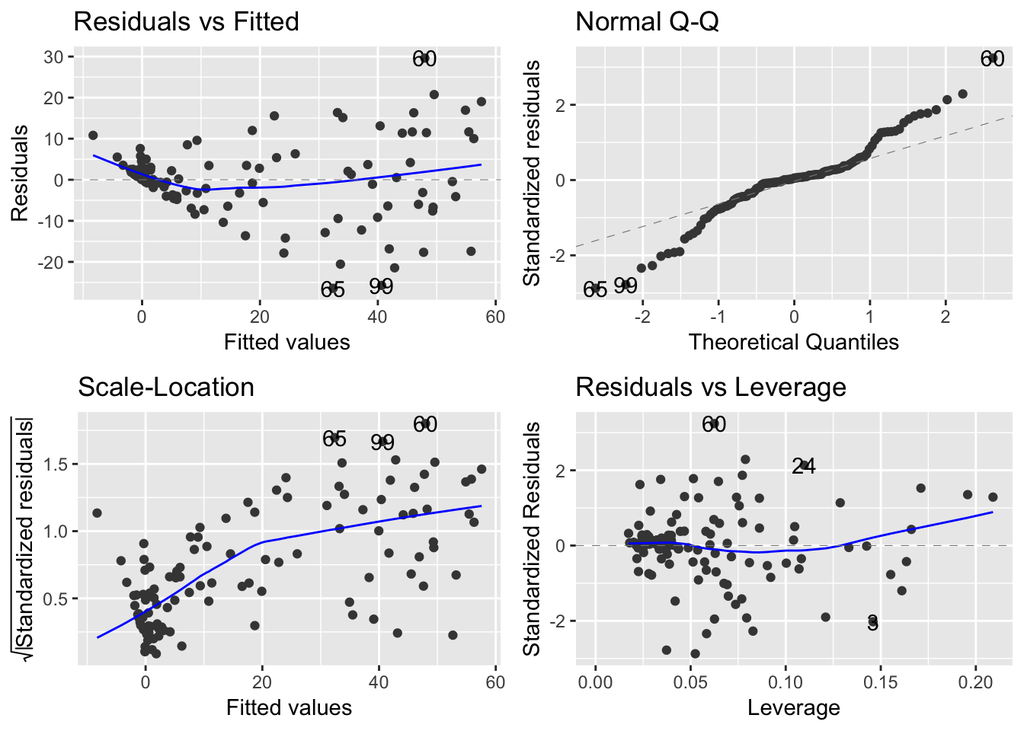

```r
autoplot(linear_model2)
```

### Comparison between Complex and Simple Model

```r
anova(linear_model_simple2, linear_model2)
```

[output not shown]

# Conclusion

In conclusion, there is neither statistical (linear) correlation between *unemployment rate* and *poverty rate* and nor practical significance, summarizing from above analysis. But the esimated, negative coefficient does at the first time surprised me a little bit. And this is against my initial thought on unemployment rate.

And throughout the process of fitting the complete models, I discovered that the access to electricity is the major indicator to poverty. Some other initial thought hold some don’t, as indicated above on the other predictors analysis of complex model on `poverty_headcount_ratio_1.90`.

What biases the analysis the most is probably the way we fill na items. We fill the na item by the most recent years one. This can be biased up or down, depending on the trend of that column and the truth. What’s better is probably to use a sample mean or regression to estimate it.

No correlation between *unemployment rate* and *poverty rate* does not necessarily mean no causation. As correlation is only for linear model. However, with these observational data, we are still unable to reach causation. To reach causation we need to rule out all the possible confounder. But for a socio-economic data as such, it’s impossible to rule out all the confounder because in real life they have too many underlying correlations with other factors. Thus we need more information, like a control study, to reach a causal conclusion

Lastly, it’s very beneficial and insightful to try to find good predictors and do analysis on them. I deeply understand it’s very tempted to add a bunch of predictors to see the r-square go up. But that will in turn make the model very very hard to explain. The reasoning behind why one coefficient not work as expected will be much harder to think through. And in that case it will have little pracitcal usage and impractical to use it to predict the future outcome.

# Extra.

```r
linear_model3 = lm(poverty_headcount_ratio_1.90~
                    acs_to_elec, data = wb_recent)

summary(linear_model3)
```

```
##
## Call:
## lm(formula = poverty_headcount_ratio_1.90 ~ acs_to_elec, data = wb_recent)
##
## Residuals:
##     Min      1Q  Median      3Q     Max
## -30.360  -1.851  -0.312   3.486  28.939
##
## Coefficients:
##             Estimate Std. Error t value Pr(>|t|)
## (Intercept) 59.02434    2.13587   27.64   <2e-16 ***
## acs_to_elec -0.58412    0.02732  -21.38   <2e-16 ***
## ---
## Signif. codes:  0 '***' 0.001 '**' 0.01 '*' 0.05 '.' 0.1 ' ' 1
##
## Residual standard error: 9.75 on 113 degrees of freedom
## Multiple R-squared:  0.8018, Adjusted R-squared:  0.8001
## F-statistic: 457.2 on 1 and 113 DF,  p-value: < 2.2e-16
```

```r
confint(linear_model3)
```

```
##                  2.5 %     97.5 %
## (Intercept) 54.7927858 63.2558922
## acs_to_elec -0.6382441 -0.5300031
```

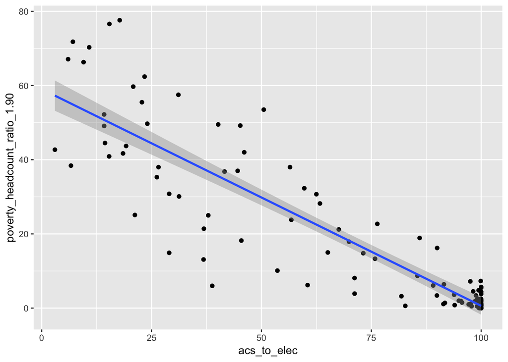

```r
ggplot(wb_recent, aes(acs_to_elec,poverty_headcount_ratio_1.90))+geom_point()+geom_smooth(method='lm')
```

Access to eletricity and poverty shows a strong negative correlation. It would be ideal if we have a per person electricity consumption that would probably lead to a more elaborate result. Future work can include digging into these two varaibles and data to see if the relationship can be strictly proven.